# Practical Machine Learning Assignment

Andrew Szwec

Tuesday, April 21, 2015

# Introduction

This report documents the Coursera Practical Machine Learning Assignment.

The objective of this assignment is to build an algorithm to predict the acitivity quality from a number of activity monitors place on a candidate’s arm, forearm, waste and dumbell during a series of 5 exercises.

The five exercises were carried out by a number of candiates and the sensor measurements were recorded in a comma separated file called pml-training.csv.

The key output of this assignment is to predict the Classe variable for a series of 20 test samples in a file called pml-testing.csv. These predictions will be submitted in a separate process for grading.

The sections below cover the necessary steps used to produce the prediction algorithm, the design decisions and any assumptions used in the process.

## Design Decisions

The Random forest model was chosen to create the machine learning algorithm for this assignment. It was chosen because tree type predictors have the benefit of being easier to interpret and display better performance in non-linear settings. Random forests have these and the additional benefits of having higher accuracy.

The types of dimensionality reduction applied were nearZeroValue, correlation and pca.

## Assumptions

The correlation between the last 53 variables remaining in the set used to train the random forest were not highly correlated enough to warrant further subseting.

## Procedure:

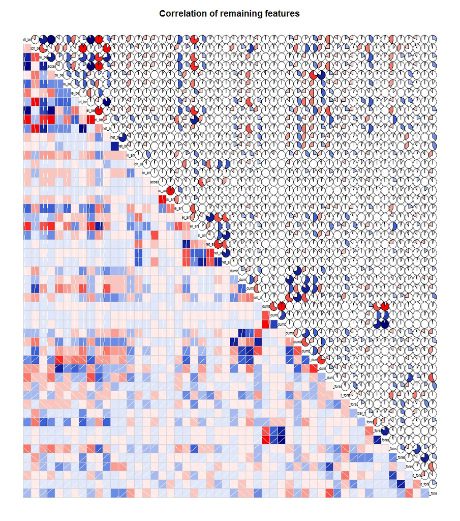

## What is the out of sample error rate

This shows that the random forest model more accurately predicts the outcome of the classe variable than the decsion tree model.

## Final Outcome

The final outcome of this assigment is to submit a series of files each containing a letter from the vector below. This vector below contains the predicted classes for the 20 sample cases required for submission.

[1] B A B A A E D B A A B C B A E E A B B B

## Appendix

The following appendice documents the procedures that were carried out to produce the machine learning algorithm and the final outcomes.

### Load Data

```r
# set working directory
setwd("~/Documents/Coursera/dataScienceSpecialisation/pracML/assignment")

# Load Data
file1 <- '/Users/andrewszwec/Documents/Coursera/dataScienceSpecialisation/pracML/assignment/pml-training.csv'
file2 <- '/Users/andrewszwec/Documents/Coursera/dataScienceSpecialisation/pracML/assignment/pml-testing.csv'

raw_train <- data.frame(read.csv(file1, header=TRUE))
raw_test <- data.frame(read.csv(file2, header=TRUE))

library(caret)
set.seed(975)
inTrain = createDataPartition(raw_train$classe, p = 0.7)[[1]]
training = raw_train[ inTrain,]     # 70% of records
testing = raw_train[-inTrain,]      # 30% of reocrds
```

### Remove categorical variables, leaving only the sensor readings

```r
df <- raw_train[,8:ncol(raw_train)]
```

### Data Preparation

Take care of:  
- Near Zero Variance columns  
- Columns with NAs  
- Inspect Correlated variables

```r
require(caret)
## Find columns with near zero variance and remove them
df_nzv <- nearZeroVar(df, saveMetrics=TRUE)
remaining <- df_nzv[which(df_nzv$nzv==FALSE),]

df_all_var <- subset(df , select=rownames(remaining))

# Remove Columsn with NAs
df_rm_na <- df_all_var[ , colSums(is.na(df_all_var)) == 0]

# Find Correlated variables
df_corr <- cor(subset(df_rm_na, select=-classe))
```

### Find correlation of variables in training data and plot chart

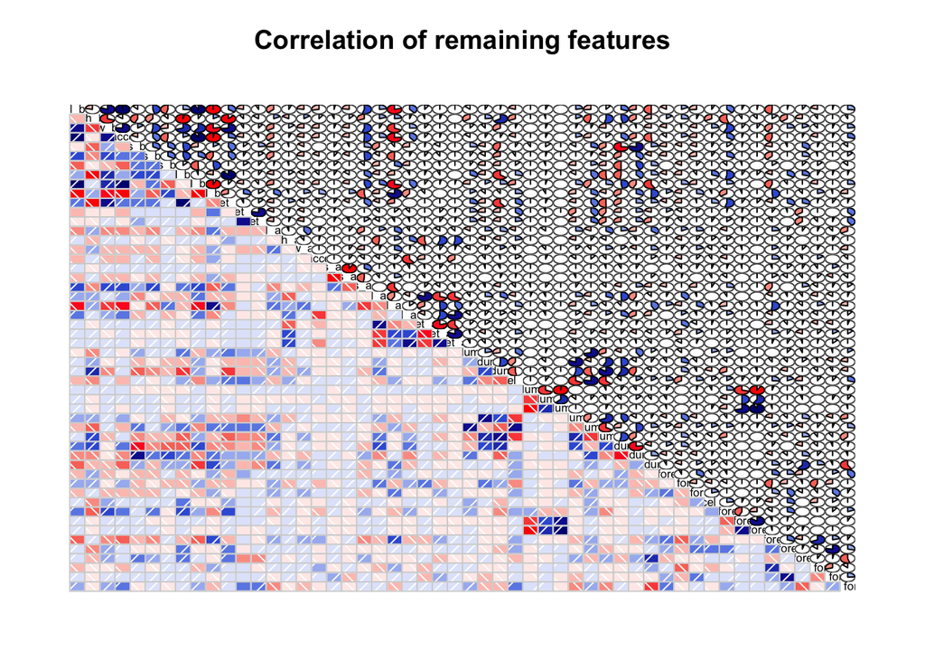

```r
## View the correlations between variables
library(corrgram)
corrgram(df_rm_na, order=FALSE, lower.panel=panel.shade,
        upper.panel=panel.pie, text.panel=panel.txt,
        col.regions=colorRampPalette(c("red","salmon","white","royalblue","navy")),
       main="Correlation of remaining features")
```

### Build Random Forest Model using 19,622 records

```r
set.seed(575656)
### Run full model!
mod_rf_full <- train(classe~ .
              ,method='rf'
              ,allowParallel=TRUE
              ,data = df_rm_na
             )
save(mod_rf_full, file = "mod_rf_full_002.RData")
```

### Print the final model details for the Random Forest Model

```r
print(mod_rf_full$finalModel)
```

```
##
## Call:
##  randomForest(x = x, y = y, mtry = param$mtry, allowParallel = TRUE)
##                Type of random forest: classification
##                      Number of trees: 500
## No. of variables tried at each split: 2
##
##         OOB estimate of  error rate: 0.36%
## Confusion matrix:
##      A    B    C    D    E class.error
## A 5578    2    0    0    0   0.0003584
## B   12 3783    2    0    0   0.0036871
## C    0   16 3405    1    0   0.0049679
## D    0    0   30 3184    2   0.0099502
## E    0    0    0    6 3601   0.0016634
```

### Look at the variable importance to the model

```r
varImp(mod_rf_full, useModel=TRUE)
```

```
## rf variable importance
##
##   only 20 most important variables shown (out of 52)
##
##                      Overall
## roll_belt              100.0
## yaw_belt                84.4
## magnet_dumbbell_z       71.7
## pitch_belt              67.2
## magnet_dumbbell_y       66.5
## pitch_forearm           62.1
## magnet_dumbbell_x       55.3
## roll_forearm            52.1
## magnet_belt_z           47.2
## accel_dumbbell_y        45.3
## magnet_belt_y           43.6
## roll_dumbbell           43.5
## accel_belt_z            42.5
## accel_dumbbell_z        38.9
## roll_arm                36.4
## accel_forearm_x         33.1
## accel_dumbbell_x        31.6
## gyros_belt_z            30.8
## yaw_dumbbell            30.2
## total_accel_dumbbell    29.5
```

### Use Random Forest model to predict values on the cross-validation set

```r
rf_full_predictions <- predict(mod_rf_full, newdata = testing)
pred <- data.frame(rf_full_predictions, classe=testing$classe)
correct <- nrow(pred[with( which(rf_full_predictions==classe), data=pred ),])
wrong <- nrow(pred[with( which(rf_full_predictions != classe), data=pred ),])
percent_correct = correct/nrow(pred)*100
percent_correct
```

```
## [1] 100
```

```r
percent_wrong = wrong/nrow(pred)*100
percent_wrong
```

```
## [1] 0
```

### The Out of sample error is…

```r
out_of_sample_error <- 1/(length(rf_full_predictions)) * sum( ( wrong )^2 )
out_of_sample_error
```

```
## [1] 0
```

### Use random forest model to predict the outcome of the 20 test cases for submission

```r
rf_submission_outcomes <- predict(mod_rf_full, newdata = raw_test)
rf_submission_outcomes
```

```
##  [1] B A B A A E D B A A B C B A E E A B B B
## Levels: A B C D E
```

### Train a decision tree model using a small random sample from the training set

```r
set.seed(575656)
# Get a random sample from the data frame with the NA columns removed
rand_train_sample <- df_rm_na[sample(1:nrow(df_rm_na), 1000, replace=FALSE),]

# Use this to train a quick decision tree model
reg_mod <- train(classe~ .
              , method='rpart'
              , preProcess=c('pca')
              , data= rand_train_sample
             )
save(reg_mod, file = "reg_mod_002.RData")
print(reg_mod$finalModel)
```

```
## n= 1000
##
## node), split, n, loss, yval, (yprob)
##       * denotes terminal node
##
## 1) root 1000 719 A (0.28 0.19 0.18 0.18 0.17)
##   2) PC12< 0.6013 746 505 A (0.32 0.2 0.22 0.16 0.1) *
##   3) PC12>=0.6013 254 155 E (0.16 0.15 0.075 0.23 0.39) *
```

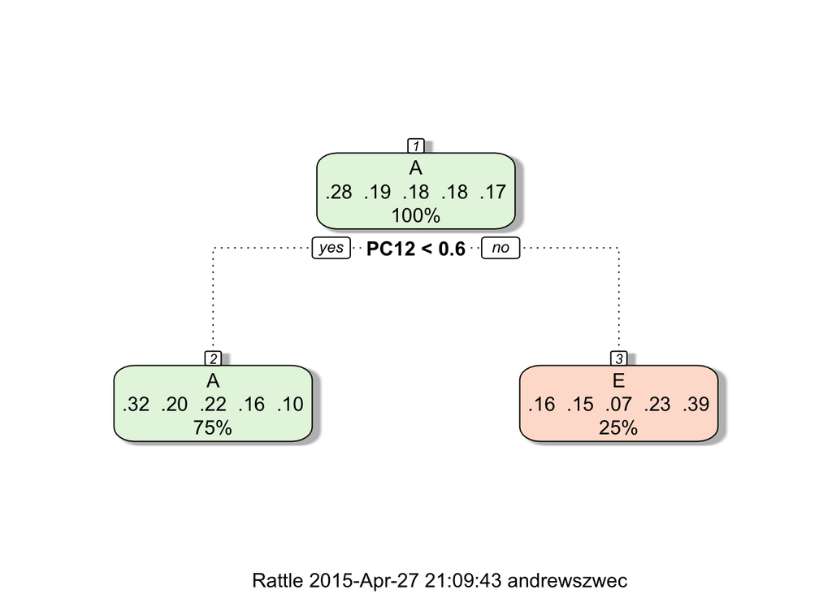

```r
# Plot Decision tree
library(rattle)
fancyRpartPlot(reg_mod$finalModel)
```

You can see that the decision tree model will only every predict Classe = A and E.

### Use the decision tree to predict the classe variable of the cross-validation set and calculate the out of sample error

```r
reg_predictions <- predict(reg_mod, newdata = testing)
pred <- data.frame(reg_predictions, classe=testing$classe)
correct <- nrow(pred[with( which(reg_predictions==classe), data=pred ),])
wrong <- nrow(pred[with( which(reg_predictions != classe), data=pred ),])
percent_correct = correct/nrow(pred)*100
percent_correct
```

```
## [1] 33.22
```

```r
percent_wrong = wrong/nrow(pred)*100
percent_wrong
```

```
## [1] 66.78
```

```r
out_of_sample_error <- 1/(length(reg_predictions)) * sum( ( wrong )^2 )
out_of_sample_error
```

```
## [1] 2624
```